# Capstone Milestone - Word Predictor

wenlarry

4/9/2017

## Overview

This milestone reports the progress towards creating a natural language processing (NLP) algorithm. It starts with raw data from SwiftKey to be processsed into a text prediction algorithm that could be accessed through a shiny application.

This milestone sequentially covers:

- Data downloads and initial wrangling
- Sampling
- Preview Sampling Data
- Preprocessing/Data Cleaning
- Tokenization (Vocabulary Vectorization)
- Construct Document Term Matirx (DTM)
- Exploratory Data Analysis with N_grams
- Testing with GloVe algorthm
- What’s Next ?

## Data Loading

- Library - readr
- Download the data, unzipped and placed only the English version of the blog.txt, news.txt and twitter.txt into a folder (dat)
- Import the 3 datasets using readLines with ‘skipNul=T’ as some of the datasets have embedded ‘nul’
- Ascertain the size of the datasets
- Download swear word list from www.bannedwordlist.com and convert to text for subsequent filter of profanities
- Snippets of the Codes are shown below:
- File Size

```
##      name     bytes num_lines       gb
## 1    blog 210160014    899288 1.957858
## 2 twitter 167105338   2360148 1.556759
## 3    news 205811889   1010242 1.917350
```

```r
twitter <- readLines("dat/en_US.twitter.txt",encoding="UTF-8",skipNul=T)

stat<-data.frame(name=c('blog','twitter','news'),
                  bytes=fileSize,
                  num_lines=c(length(blog),
                              length(twitter),
                              length(news)))

stat['gb']<-stat['bytes']/107341824

download.file(url="http://www.bannedwordlist.com/lists/swearWords.txt",
              destfile="swearWord.txt",method="curl")
```

## Sampling

Given the large datasets, we decide to sample 20% plus of the total lines of the 3 datasets.

Snippets of the Codes are shown below:

```r
blogSample<-sample (blog,200000)
```

## Sampling Data Preview

Here is an extract from twitterSample

```
## [1] "I'm reading Frank:The Voice by James Kaplan. Thoroughly engaging story and brilliant writing about Sinatra. Also get Gil Scott Heron's last."
```

Libraries - Quanteda; ggplot2

We primarily use Quanteda package to combine the sample datasets and plot the dispersion A corpus of the combined 3 datasets would be created for plotting a lexical dispersion plot with ggplot2.

Another reason for choosing a lexical dispersion plot is because you can just supply the actual word and get the frequencies, in terms of tokens, across all the 3datasets. This is useful for future tweaks in improving your algorithm. (Just substitute “Words” in the code with your chosen word to get the tokens across all 3 datasets) .

Snippets of the codes are shown below:

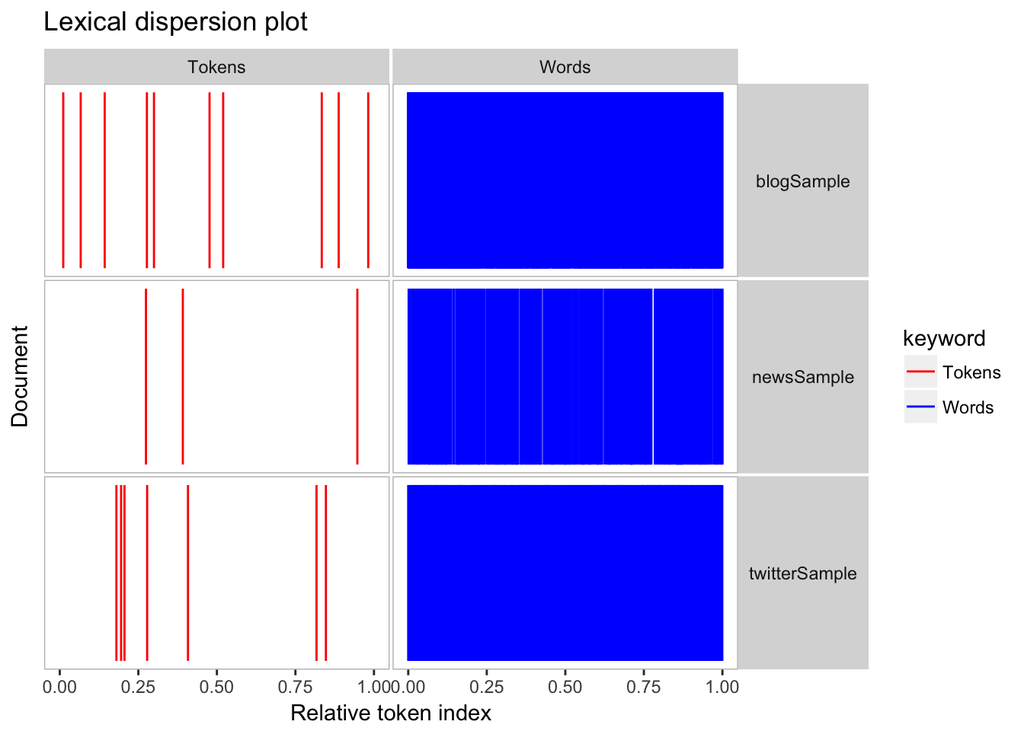

```r
g<-textplot_xray(kwic(Qsample,"Tokens"),

                 kwic(Qsample,"Words"))

g+aes(color=keyword) +scale_color_manual(values=c('red', 'blue') )

# Qsample is the combined 3 sample data sets (i.e blogSample, newsSample,   #twitterSample)
```

## Preprocessing / Data Cleaning

We begin with some basic cleaning that involves:

- Substitution of short form English words to long forms (fullEng)
- Remove all non alpha English characters except quotes and hyphens (cleanText)
- Remove hash tags, etc from twitter.txt (untwitter)

Snippets of the codes are shown below

```r
hashClean<-function(t){
        t<-gsub('#','',t)
        return(t)
}
twitterClean<-function(t){
        t<-gsub('http\\S+\\s*','',t)
        return(t)
}
fullEng<-function(t){
        t<-gsub(pattern="won't",replacement="will not",t)
        return(t)
}
```

## Tokenization (Vocabulary Vectorization)

We use the text2vec package from this stage forward. We choose this package because texts take up a lot of memory, but vectorized texts usually do not, as they are stored as sparse matrices. R’s copy-on-modify semantics read the whole collection of text documents into RAM and then process it as a single vector. This increase the memory and text2vec is the choice for a fast and memory friendly process.

(The creator of text2vec has provided comprehensive notes for usage. The notes contain examples and codes for tokenization, stemming, dtm creation ,etc. Google: ‘Analyzing text with text2vec package R’)

We do not stem at this stage as we care more about the efficacies of the ngrams that we are consructing. We can always stem at the next stage should we need to improve on the algorithm to process the text more effectively.

When we clean/tokenize and apply the function to our Samples, we note that the time taken is only 18 minutes with text2vec. This step takes the most processing time in the whole exercise.

Snippets of the codes are shown below

```r
# paste cleaned toens to Samples
xtokenizer<-function(v,tokenizer=word_tokenizer){
 v%>%
  hashClean%>%
  twitterClean%>%
  fullEng%>%
  textClean%>%
  tokenizer
}
```

## Document Term Matrix (DTM)

We build ‘stopwords’ list to pass through the vocabulary creation function. This is because ‘stopwords’ can only be filtered after tokenization. Concurrently, we strip swear words from the tokens using the ‘swearWord’ list that was built earlier. (This fulfills the requirement to remove profanities from the text).

We create the iterator on the tokens and generate the vocabulary from the iterator.

Snippets of the Codes are shown below:

```r
stopwords<-c("i","my", "me","myself","we","our","ours","ourselves","you",
             "your","yours")

swsw<-c(stopwords,swearWord)

it<-itoken(tokens)
vocab<-create_vocabulary(it,ngram=c(1L,1L),stopwords=swsw)

pruned_vocab=prune_vocabulary(vocab,term_count_min=2, doc_proportion_max = 0.5)

it<-itoken(tokens)
v_vectorizer<-vocab_vectorizer(pruned_vocab)
dtm<-create_dtm(it,v_vectorizer)
```

## Build Unigram, Bigram and Trigram

We construct the Unigram, Bigram and Trigram as frequency tables, in descending order.

We plot top terms that fit the 3 ngrams.

Snippets of the codes are given below. Just repeat the codes for unigram and bigram.

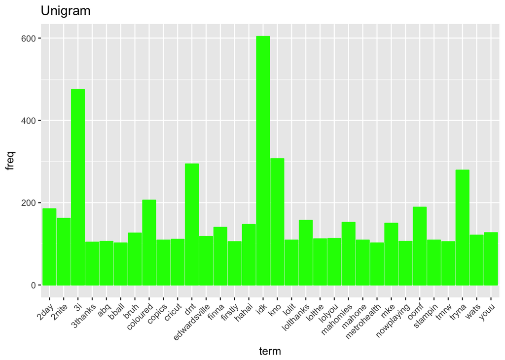

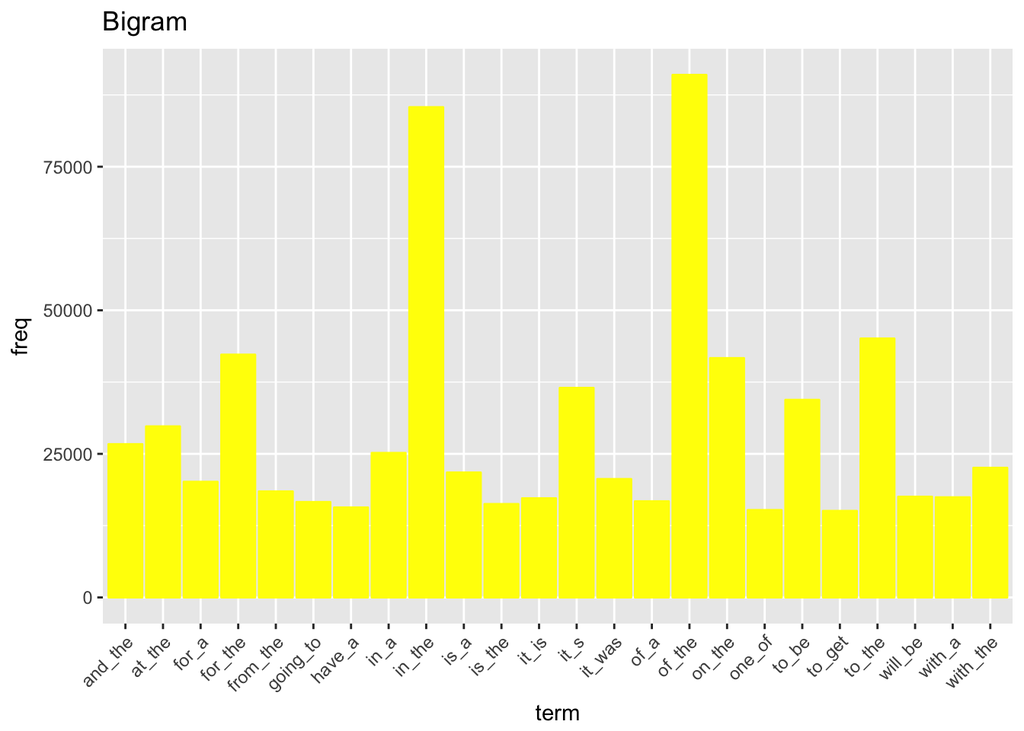

[figure not shown]

```r
# trigram
freq <- sort(colSums(as.matrix(dtm3)), decreasing=TRUE)
wf <- data.frame(term=names(freq), freq=freq)
# Plot
subset(wf, freq>2500)    %>%
        ggplot(aes(term, freq)) +
        geom_bar(stat="identity", fill="orange", colour="orange")+
        theme_minimal()+labs(title= "Trigram")
```

## Exploratory Data Analysis

N-gram model is a type of probablistic lingusitic model for predicting the next item in a sequence in the form of a n-1 order. The 2 benefits in using n-gram model and the algorithm that use them are simplicity and scalability. With larger n, a model can store more context.

The terms in the unigram , bigram and trigram are 152673 (3.7mg) 4012986 (116.4mb) and 4864461 (145.6mb) respectively. We can see these data from the values output in RStudio.

The final output (shiny app) is constrained by 1 gigabyte of data, so we still have space to expand our sample, build more ngrams, etc, if improvements are required.

## Test with GloVe Algorithm

GloVe is an unsupervised learning algorithm for obtaining vectore representations for words. See (http://nip.Stanford.edu/projects/glove/).

(The creator of text2Vec has provided comprehensive notes, examples and codes for GloVe. Google (’Analyzing text with text2vec package R ).

Snippets of the Codes are shown below:

```r
# Follow through with all previous codes before DTM construction.
pvocab=prune_vocabulary(vocab,term_count_min=5L)

it<-itoken(tokens)

cooccurence_vectorizer<-vocab_vectorizer(pvocab,grow_dtm = FALSE,
                                         skip_grams_window=5L)

tcm<-create_tcm(it,cooccurence_vectorizer)

glove=GlobalVectors$new(word_vectors_size=100, vocabulary=vocab,x_max=10)

fit(tcm,glove,n_iter=20)

word_vectors<-glove$get_word_vectors()

# build the word vectors
novels<-word_vectors["stories",,drop=FALSE]-
        word_vectors["pictures",,drop=FALSE]   -
        word_vectors["movies",, drop=FALSE] -
        word_vectors["almost",, drop=FALSE]

cos_sim=sim2(x=word_vectors,y=novels,method="cosine",norm="l2")

head(sort(cos_sim[,1],decreasing =TRUE),5)

# probabilities would be shown against each word provided
```

## Next Step ?

- Refine GloVe algorithm and test it with more texts.
- Should the GloVe algorithm be a challenge, we would revert to a conventional back-off model to construct the algorithm. In this eventuality, we plan to use the Katz Back-Off (KBO) model.
- Build the shiny app as the front end device for the next word prediction.